# Random Variable Generation: Inverse Transform, Box–Muller, and Uniform Sampling on the Disk

Author

Jyotishka Datta

Published

August 24, 2026

# 1 Overview

These notes continue directly from the previous set, *CDF, Probability Integral Transformation, and Random Variable Generation*. There we studied how to **describe** a distribution through its cumulative distribution function, its empirical CDF, and its quantiles, ending with the generalized inverse

$$F^{-1}(u) = \inf\{x \mid F(x) \ge u\}, \qquad 0 \le u \le 1.$$

Here we take the complementary point of view: given nothing but a stream of $\text{Uniform}(0,1)$ numbers, how do we **generate** observations from some other distribution of interest? Every algorithm below is an answer to that question. We treat three ideas in increasing order of sophistication:

- **Inverse-transform sampling**, which works whenever we can invert the CDF;
- **Change-of-variables (Jacobian) methods**, which let us transform one distribution into another;
- the **Box–Muller transform** and **uniform sampling on the disk**, two classic applications of the change-of-variables idea.

**Prerequisites from the previous notes**

We assume familiarity with the CDF $F$, the quantile function / generalized inverse $F^{-1}$, and the fact that R’s `runif()` supplies independent $\text{Uniform}(0,1)$ draws. Everything else is developed from scratch.

# 2 The Probability Integral Transform

The whole enterprise of random-variable generation rests on a single theorem, which is why we open with it rather than close the previous notes with it.

## 2.1 Theorem

Suppose $X$ has continuous CDF $F$. Then $U = F(X)$ has a $\text{Uniform}(0,1)$ distribution.

Conversely, if $U \sim \text{Uniform}(0,1)$, then $X = F^{-1}(U)$ has distribution function $F$.

### 2.1.1 Proof

$$\begin{align}
&\Pr(F^{-1}(U) \leq x) \\
&= \Pr(U \leq F(x)) \qquad (F \text{ is right-continuous, so } \{u : F^{-1}(u) \leq x\} = \{u : u \leq F(x)\}) \\
&= F(x) \qquad\qquad\quad\ \ (\text{because } \Pr(U \leq u) = u \text{, when } U \text{ is uniform on } [0,1]).
\end{align}$$

The converse statement is what we actually use to generate data: if we can compute $F^{-1}$, then feeding uniform numbers through it produces draws from $F$. This is **inverse transform sampling**, and it is the first method we develop.

# 3 Inverse-CDF (Inverse Transform) Sampling

The recipe is short:

1. Generate $U \sim \text{Uniform}(0,1)$.
2. Return $X = F^{-1}(U)$.

The only requirement is that we can evaluate $F^{-1}$ in closed form (or at least numerically). Two distributions where this is easy are the logistic and the exponential.

## 3.1 Logistic Distribution

Consider a logistic density

$$f(x\mid\lambda)
=
\frac{\lambda e^{-\lambda x}}
{(1+e^{-\lambda x})^2}.$$

Its CDF is

$$F(x\mid\lambda)
=
\frac{1}
{1+e^{-\lambda x}},$$

which we can solve explicitly for $x$. Setting $F(x) = u$ and rearranging gives the inverse CDF

$$F^{-1}(u\mid\lambda)
=
-\frac{1}{\lambda}
\log\!\left(
\frac{1}{u}-1
\right).$$

### 3.1.1 R Function

```r
logistic_rvgen <- function(lambda, n = 1) {
  u <- runif(n)
  -log((1 / u) - 1) / lambda
}
```

### 3.1.2 Verification

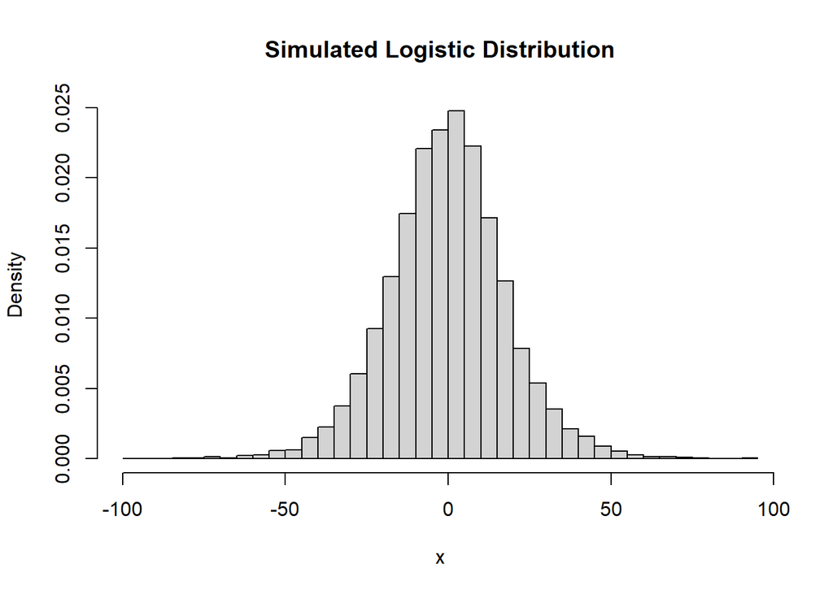

Figure 1: Histogram of 10,000 logistic draws generated by inverting the CDF.

```r
set.seed(3504)

x <- logistic_rvgen(lambda = 0.1, n = 10000)

hist(
  x,
  probability = TRUE,
  breaks = 40,
  main = "Simulated Logistic Distribution",
  xlab = "x"
)
```

The histogram resembles the theoretical logistic density, as expected.

## 3.2 Exponential Distribution

Suppose $X \sim \text{Exp}(\lambda)$, with CDF

$$F(x) = 1 - e^{-\lambda x}, \qquad x \ge 0.$$

Solving $F(x) = u$ gives $x = -\tfrac{1}{\lambda}\log(1-u)$. Because $1 - U$ is itself $\text{Uniform}(0,1)$ whenever $U$ is, we may replace $1-U$ by $U$ and use the tidier form

$$X = -\frac{\log(U)}{\lambda}.$$

We will reuse this exact formula in a moment when we generate normals.

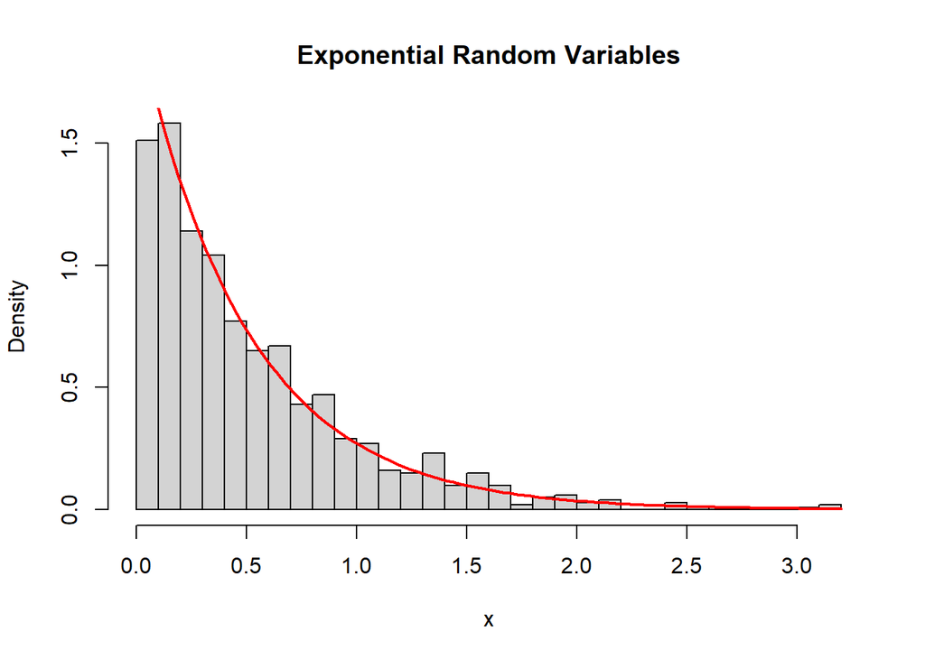

Figure 2: Exponential draws (rate = 2) with the true density overlaid in red.

```r
set.seed(3504)

lambda <- 2
u <- runif(1000)
x <- -log(u) / lambda

hist(
  x,
  probability = TRUE,
  breaks = 30,
  main = "Exponential Random Variables",
  xlab = "x"
)

curve(dexp(x, lambda), add = TRUE, col = "red", lwd = 2)
```

# 4 Transformations and the Change-of-Variables Formula

Inverse-transform sampling fails the moment $F^{-1}$ has no closed form, and the standard normal is the most popular example. To handle it we need a second tool: the rule for how a density changes when we apply a transformation. This is the key that unlocks both the Box–Muller transform and uniform sampling on the disk.

## 4.1 One dimension

Let $X \sim p_X(x)$ and let $Y = T(X)$ for a smooth, strictly increasing map $T:\mathbb{R}\to\mathbb{R}$. Matching cumulative probabilities,

$$P_Y(T(x)) = \Pr(Y \le T(x)) = \Pr(X \le x) = P_X(x).$$

Differentiating both sides with respect to $x$ and applying the chain rule yields

$$p_Y(T(x)) = \left(\frac{d}{dx}T(x)\right)^{-1} p_X(x).$$

In words: the density is rescaled by the reciprocal of how much $T$ stretches the axis at that point.

## 4.2 Several dimensions

The same reasoning generalizes to a one-to-one map $T:\mathbb{R}^n \to \mathbb{R}^n$ taking $X$ to $Y = T(X)$:

$$p_Y(T(x)) = \frac{1}{\lvert J_T \rvert}\, p_X(x),$$

where $\lvert J_T \rvert$ is the absolute value of the determinant of the Jacobian matrix of $T$. Equivalently, if we already know the density of $Y$ and want the density of $X = T(x)$ in the *new* coordinates, we **multiply** by $\lvert J_T \rvert$. That is the direction we need for the disk problem below.

The two applications that follow both rely on the polar-coordinate map $T:(r,\theta)\mapsto(x_1,x_2)$ given by $x_1 = r\cos\theta$, $x_2 = r\sin\theta$, whose Jacobian determinant is

$$J_T =
\begin{bmatrix}
\cos\theta & -r\sin\theta \\
\sin\theta & \ r\cos\theta
\end{bmatrix},
\qquad
\lvert J_T \rvert = r .$$

# 5 Generating Normal Random Variables: Box–Muller

Generating from the Normal distribution is awkward for inverse-transform sampling because the standard normal CDF

$$\Phi(x) = \int_{-\infty}^{x} \frac{1}{\sqrt{2\pi}}\, e^{-y^2/2}\, dy,
\qquad x \in \mathbb{R},$$

has no closed-form inverse. Remarkably, though, generating a *pair* of independent normals is easy once we move to polar coordinates.

## 5.1 Derivation

Let $X_1, X_2 \sim N(0,1)$ be independent. Their joint density is

$$p(x_1, x_2) = \frac{1}{2\pi}\, e^{-(x_1^2 + x_2^2)/2}.$$

Change to polar coordinates $x_1 = r\cos\theta$, $x_2 = r\sin\theta$. Since $x_1^2 + x_2^2 = r^2$ and the Jacobian is $\lvert J_T \rvert = r$, multiplying by the Jacobian gives the joint density in $(r,\theta)$:

$$g(r,\theta) = \underbrace{r\, e^{-r^2/2}}_{\text{density of } R}
\;\cdot\;
\underbrace{\frac{1}{2\pi}}_{\text{density of } \theta},
\qquad r \ge 0,\ \theta \in [0,2\pi].$$

Because the density **factorizes**, $R$ and $\theta$ are independent, with

$$\theta \sim \text{Uniform}(0, 2\pi),
\qquad
R \text{ has density } r\, e^{-r^2/2}.$$

Now look at $S = R^2$. Its CDF is

$$\Pr(R^2 \le s) = \Pr(R \le \sqrt{s})
= \int_0^{\sqrt{s}} r\, e^{-r^2/2}\, dr
= 1 - e^{-s/2},$$

which turns out to be the CDF of an $\text{Exp}(\text{rate} = 1/2)$ random variable, which is a $\chi^2_2$. We already know how to sample that: using the exponential formula $X = -\log(U)/\lambda$ with $\lambda = 1/2$,

$$R^2 = -2\log(U_1)
\quad\Longrightarrow\quad
R = \sqrt{-2\log(U_1)}.$$

Combining $R$ and $\theta$ and mapping back to Cartesian coordinates gives the **Box–Muller transform**.

## 5.2 Algorithm

Generate $U_1, U_2 \sim \text{Uniform}(0,1)$ and set

$$X_1 = \sqrt{-2\log(U_1)}\,\cos(2\pi U_2),
\qquad
X_2 = \sqrt{-2\log(U_1)}\,\sin(2\pi U_2).$$

Then $X_1$ and $X_2$ are **two independent** $N(0,1)$ draws. The method yields two normals for every two uniforms consumed, which is part of its appeal.

## 5.3 Implementation

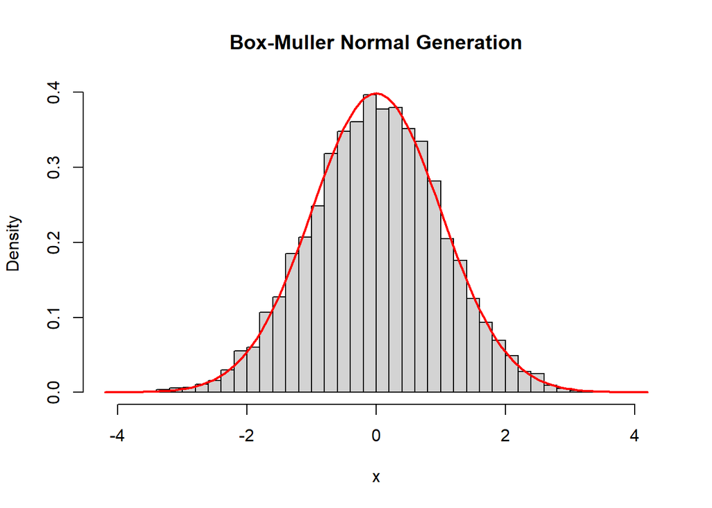

Figure 3: Histogram of 10,000 Box–Muller normal draws with the standard normal density in red.

```r
set.seed(3504)

n <- 5000
u1 <- runif(n)
u2 <- runif(n)

R <- sqrt(-2 * log(u1))
theta <- 2 * pi * u2

x1 <- R * cos(theta)
x2 <- R * sin(theta)

z <- c(x1, x2)   # 2n = 10,000 independent N(0,1) draws

hist(
  z,
  probability = TRUE,
  breaks = 40,
  main = "Box-Muller Normal Generation",
  xlab = "x"
)

curve(dnorm(x), add = TRUE, col = "red", lwd = 2)
```

A histogram gives a rough visual check; a quantile–quantile plot is another but more informative, because departures from normality show up as departures from the straight reference line. We will return to QQ plots and other goodness of fit tests in another module.

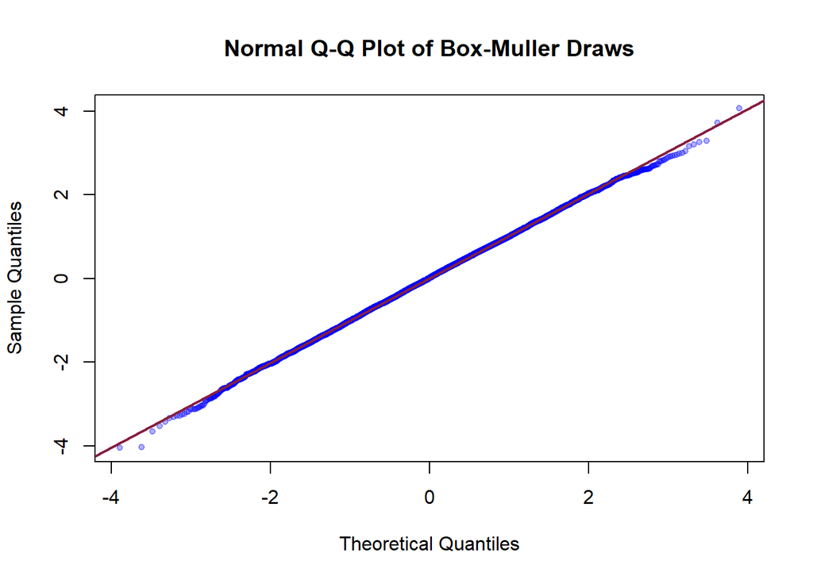

Figure 4: Normal Q–Q plot of the Box–Muller draws; near-linearity indicates approximate normality.

```r
qqnorm(z, main = "Normal Q-Q Plot of Box-Muller Draws", pch = 20,
       col = rgb(0, 0, 1, 0.3))
qqline(z, col = "#861F41", lwd = 2)
```

**Two practical notes**

- `runif()` can in principle return exactly `0`, and `log(0)` is `-Inf`. The event has probability zero in exact arithmetic but is worth guarding against in production code (e.g. resample any $U_1 = 0$).
- Trigonometric calls are relatively expensive. Marsaglia’s **polar method** is a common variant that replaces $\cos$ and $\sin$ with a small rejection step; it produces the same distribution and is often faster.

# 6 Uniform Points on the Unit Disk

Our second application is to sample points spread **uniformly** over the unit disk $\{(x,y) : x^2 + y^2 \le 1\}$, whose density is

$$p(x, y) =
\begin{cases}
\dfrac{1}{\pi} & \text{if } x^2 + y^2 \le 1, \\[4pt]
0 & \text{otherwise.}
\end{cases}$$

## 6.1 Why the naive method fails

A tempting shortcut is to draw a radius $R \sim \text{Uniform}(0,1)$ and an angle $\theta \sim \text{Uniform}(0, 2\pi)$ and set $X = R\cos\theta$, $Y = R\sin\theta$. However, this does **not** produce uniform points, rather it crowds them near the center. The reason is the area element: in polar coordinates a thin ring at radius $r$ has area $2\pi r\, dr$, which grows with $r$. Spreading the radius uniformly therefore packs too much probability into the small inner rings and too little into the large outer ones.

## 6.2 The correct method via change of variables

To fix this, apply the change-of-variables formula. Multiplying the Cartesian density $1/\pi$ by the Jacobian $\lvert J_T \rvert = r$ gives the density in polar coordinates:

$$p(r, \theta) = \frac{r}{\pi},
\qquad r^2 \le 1,\ \theta \in [0, 2\pi].$$

Integrating out $\theta$ gives the marginal density of the radius,

$$p(r) = \int_0^{2\pi} \frac{r}{\pi}\, d\theta = 2r,
\qquad 0 \le r \le 1,$$

and the conditional density of the angle,

$$p(\theta \mid r) = \frac{p(r,\theta)}{p(r)} = \frac{1}{2\pi},$$

so $\theta \sim \text{Uniform}(0, 2\pi)$, independent of $R$. Finally, the CDF of the radius is

$$P(r) = \int_0^{r} 2s\, ds = r^2,$$

which we invert by inverse-transform sampling: setting $r^2 = U_1$ gives $R = \sqrt{U_1}$. The square root is exactly the correction the naive method was missing.

## 6.3 Algorithm

Generate $U_1, U_2 \sim \text{Uniform}(0,1)$ and set

$$R = \sqrt{U_1},
\qquad
\theta = 2\pi U_2,
\qquad
X = R\cos\theta,
\qquad
Y = R\sin\theta.$$

## 6.4 Implementation

We plot the naive and correct schemes side by side so the difference is visible.

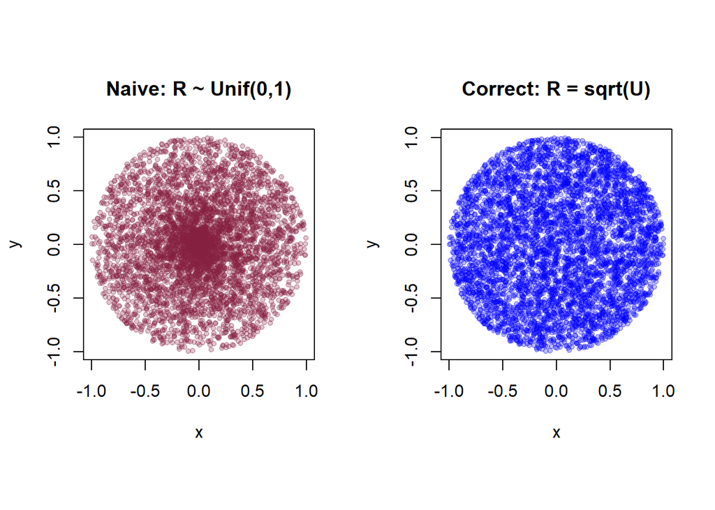

Figure 5: 5000 samples on the unit disk. Left: the naive R ~ Uniform(0,1) scheme clusters near the center. Right: R = sqrt(U) spreads points evenly.

```r
set.seed(3504)

n <- 5000
u1 <- runif(n)
u2 <- runif(n)
theta <- 2 * pi * u2

# Naive (incorrect) scheme: R ~ Uniform(0,1)
r_naive <- u1
x_naive <- r_naive * cos(theta)
y_naive <- r_naive * sin(theta)

# Correct scheme: R = sqrt(U)
r_ok <- sqrt(u1)
x_ok <- r_ok * cos(theta)
y_ok <- r_ok * sin(theta)

par(mfrow = c(1, 2), pty = "s")

plot(x_naive, y_naive, asp = 1, pch = 20, col = rgb(0.52, 0.12, 0.25, 0.25),
     main = "Naive: R ~ Unif(0,1)", xlab = "x", ylab = "y")

plot(x_ok, y_ok, asp = 1, pch = 20, col = rgb(0, 0, 1, 0.25),
     main = "Correct: R = sqrt(U)", xlab = "x", ylab = "y")
```

The plots make the difference obvious, but we can also confirm it numerically without relying on the picture. For a genuinely uniform disk, the fraction of points falling inside radius $0.5$ should equal the area ratio, $\pi(0.5)^2 / \pi(1)^2 = 0.25$. The naive scheme instead puts half its points there, since $\Pr(R < 0.5) = 0.5$ when $R \sim \text{Uniform}(0,1)$.

```r
c(naive = mean(r_naive < 0.5), correct = mean(r_ok < 0.5))
```

```
  naive correct
 0.5068  0.2562
```

The correct method lands near $0.25$, exactly as the area argument predicts.

**Generalization**

The same idea extends to an axis-parallel ellipse $\{(x,y) : x^2/a^2 + y^2/b^2 \le 1\}$: sample uniformly on the unit disk as above, then rescale by $(a, b)$ along the two axes.

# 7 Key Takeaways

- The **probability integral transform** is the theoretical foundation for all of random-variable generation: $F^{-1}(U)$ has distribution $F$.
- **Inverse-transform sampling** is the method of choice whenever $F^{-1}$ is available in closed form, as for the logistic and exponential distributions.
- When $F^{-1}$ is unavailable, the **change-of-variables (Jacobian) formula** lets us transform a distribution we *can* sample into the one we want.
- The **Box–Muller transform** uses this idea in polar coordinates to turn two uniforms into two independent standard normals, exploiting the fact that $R^2 \sim \chi^2_2 = \text{Exp}(1/2)$.
- **Uniform sampling on the disk** requires the correction $R = \sqrt{U}$; the naive $R \sim \text{Uniform}(0,1)$ scheme clusters points near the center because it ignores the $r$ factor in the area element.